# Презентация по лабораторной работе №5

Аппарат сетей Петри

Люпп Софья Романовна

kulyabov-ds@rudn.ru

Российский университет дружбы народов

2026-05-13

# Информация

## Докладчик

- Люпп Софья Романовна
- студентка НКНбд-01-23
- кафедра теории вероятностей и кибербезопасности
- Российский университет дружбы народов им. П. Лумумбы
- 1132236039@rudn.ru
- https://github.com/srluipp

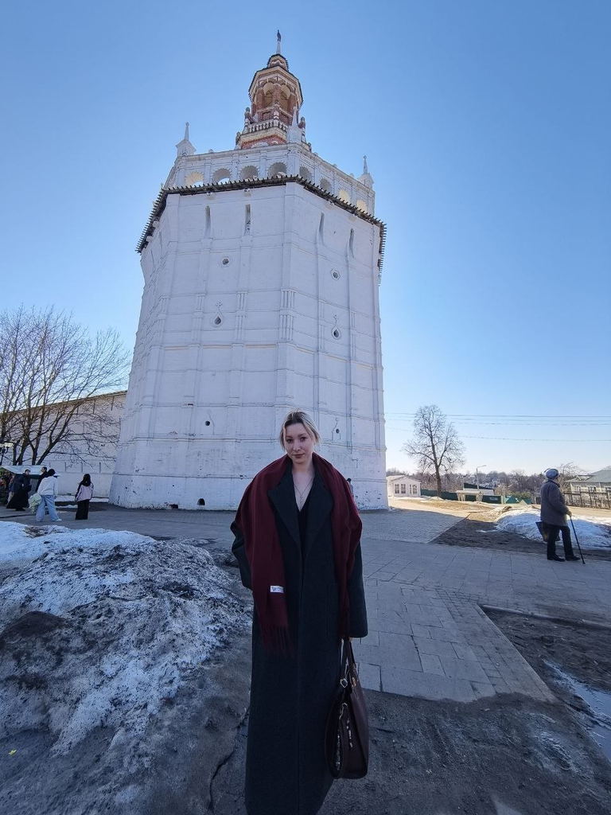

# Вводная часть

## Актуальность

Модель Росса актуальна для анализа надёжности технических систем с резервированием и ремонтом, например серверов, производственных линий и телекоммуникационного оборудования, где важно оценить время до отказа системы.

Модели массового обслуживания широко применяются для исследования очередей и загрузки ресурсов в банках, компьютерных сетях, call-центрах и транспортных системах, позволяя оптимизировать число обслуживающих устройств и уменьшать время ожидания.

## Объект и предмет исследования

Объект исследования: дискретно-событийное моделирование Предмет исследования: модель Росса

## Цели

Изучить дискретно-событийное моделирование, модели М/М/С и модель Росса.

## Задачи

1. Изучить теорию по дискретно-событийному моделированию и модель Росса;
2. Создать необходимые скрипты по заданию;
3. Выполнить отчет и презентацию, преобразовать документацию в формате Quarto и выполнить литературный код.

## Материалы и методы

В качестве материалов к выполнению лабораторной работы была использована работа Имитационное моделирование. Практикум. (А. В. Королькова Кулябов Д. С.)

# Выполнение работы

Начинаю лабораторную с реализации модели М/М/С (рис. 1).

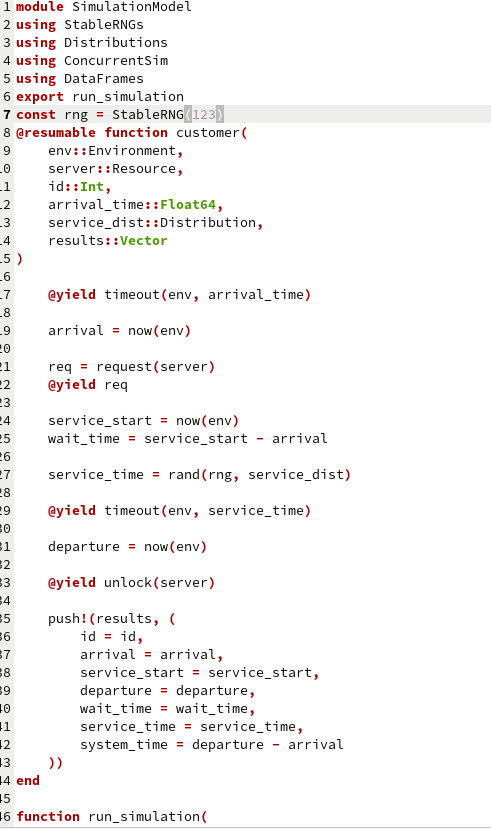

Рисунок 1: Создание скрипта в src

## run_simulation

Записываю скрипт run_simulation для модели М/М/2 с данными по заданию параметрами (рис. 2).

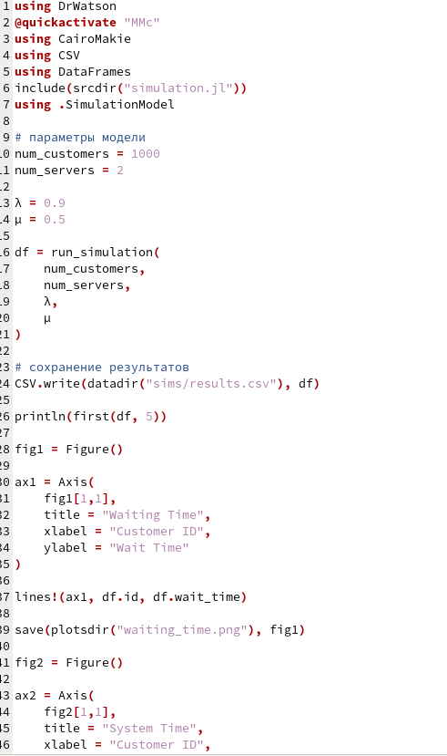

Рисунок 2: Создание скрипта run_simulation

## Выводы в консоль

В консоль получаю вывод DataFrame с параметрами модели (рис. 3).

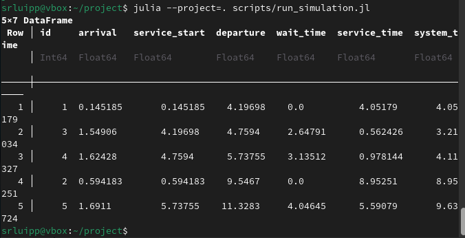

Рисунок 3: Параметры модели

## График времени нахождения в системе

В plots появился график времени нахождения в системе (рис. 4)

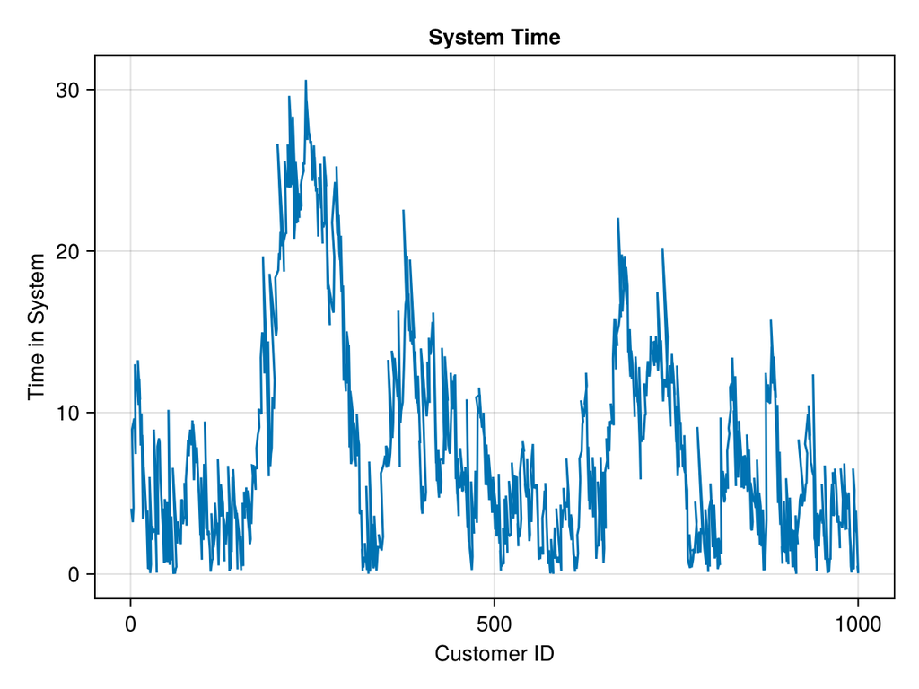

## График времени ожидания обслуживания

В plots появился график времени ожидания обслуживания (рис. 5)

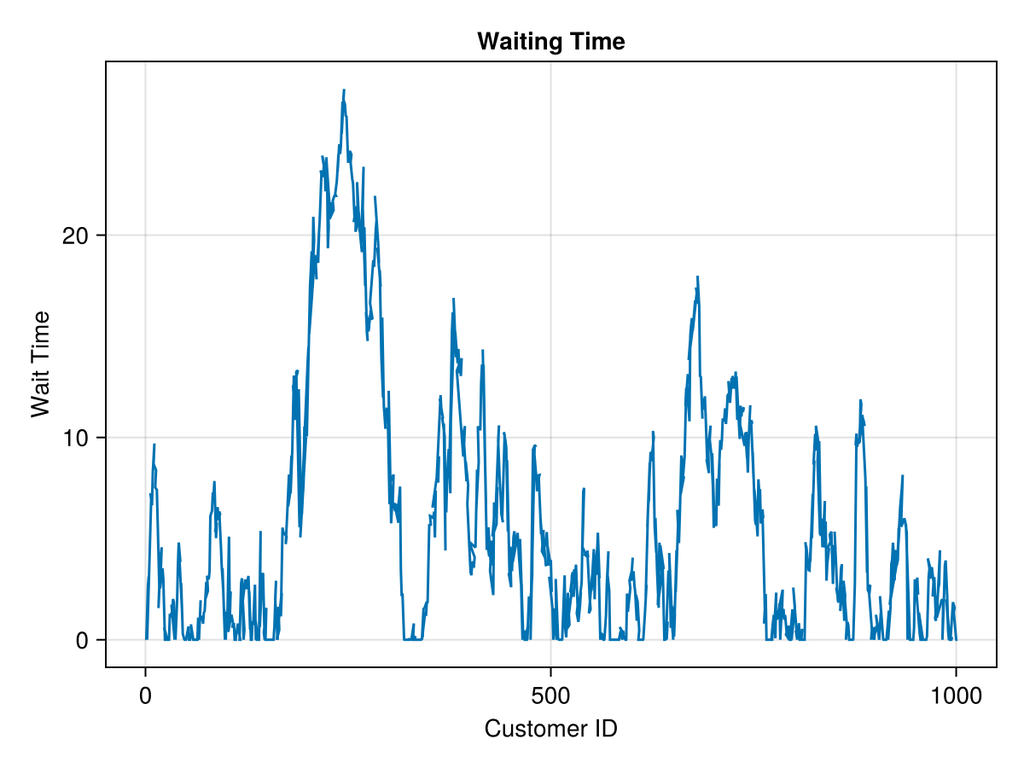

Рисунок 5: Waiting time

## Добавление нескольких машин в симуляцию

Добавляю нескольких ремонтников и делаю прогон для разного количества машин (рис. 6).

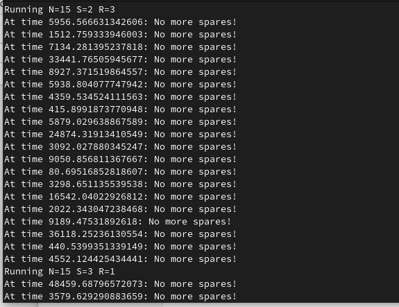

Рисунок 6: Вывод в консоль для разного кол-ва машин

## График влияния параметра s

Делаю вывод о влиянии количества машин s на систему по получившемуся графику (рис. 7).

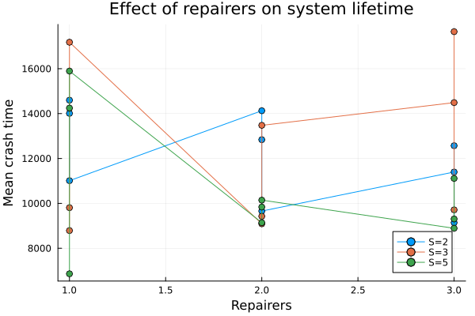

Рисунок 7: График после добавления количества машин

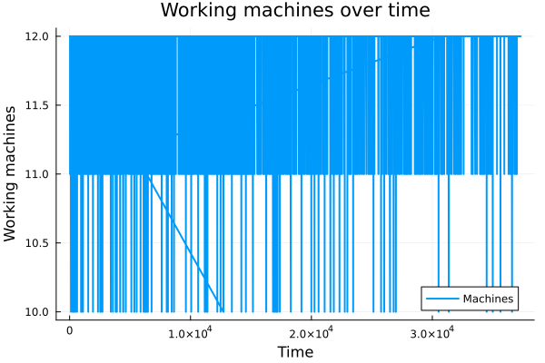

## Анализ

Провожу мониторинг загрузки ремонтника, средней длины очереди на ремонт (рис. 9).

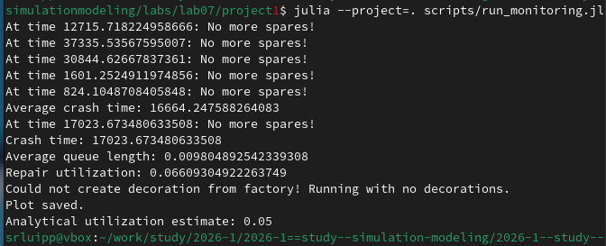

Рисунок 9: Вывод реализации в консоль

## Результаты

Результатами данной лабораторной работы являются получившиеся графики и анимация в plots

## Итоговый слайд

(рис. 10).

[figure not shown]

Рисунок 10: Дискретно-событийное моделирование